# Variance of User Feedback Frequency

Julian Frattini

2026-04-09

This document analyses the variance of responses to the question “How often is end user feedback provided?” (`v_368`) across demographic factors. For analysis, we follow the 3-step framework for statistical causal inference as summarized by Siebert.[^1]

```r
v <- "v_368"
vname <- "user feedback frequency"

# minimum likelihood of responses to be considered "common"
level.common <- 0.2
```

## Variables

We consider the following demographic factors:

| Code | Name | Question | Type |
| --- | --- | --- | --- |
| `v_23` | country | In which country are you personally located? | categorical |
| `v_3` | size | How many people are involved in your project? | numeric |
| `v_457` | way of working | How would you personally characterise the way your project works? | ordinal |
| `v_1` | sector | Please select the main industrial sector of your project or the application domain of the software you build. | categorical |
| `v_16` | external | Does your project involve external partners? | binary |
| `v_357` | distributed | Is your project distributed? | binary |
| `v_377` | virtualization | Do you tend to work from home, on-site, or both? | ordinal |
| `v_17` | role | What is the main role you occupy in your project? | categorical |

## Data Analysis

We analyze the variance of the response variable following established practices of Bayesian data analysis.[^2]

```r
d <- load_data(run = "2024", data_path = "../../data", file = "runs/napire2024/data_cleaned_2024.csv") %>%
  select(lfdn, v_3, Country, v_1, v_457, v_16, v_357, v_377, v_17, !!sym(v)) %>%
  drop_na()

str(d)
```

```
## 'data.frame':    355 obs. of  10 variables:
##  $ lfdn   : int  100 102 104 106 108 109 110 111 115 117 ...
##  $ v_3    : int  20 5 8 20 25 25 9 7 20 6 ...
##  $ Country: chr  "Germany" "Sweden" "Germany" "Sweden" ...
##  $ v_1    : Factor w/ 22 levels "Agriculture",..: 5 2 6 12 6 15 2 2 10 17 ...
##  $ v_457  : Ord.factor w/ 6 levels "Agile"<"Rather agile"<..: 5 1 3 2 1 4 2 5 1 4 ...
##  $ v_16   : Factor w/ 3 levels "Yes","No","I don't know": 1 2 1 2 1 1 2 2 1 2 ...
##  $ v_357  : logi  TRUE FALSE TRUE FALSE TRUE TRUE ...
##  $ v_377  : Ord.factor w/ 6 levels "Almost completely on-site"<..: 3 1 3 2 1 5 2 3 4 3 ...
##  $ v_17   : Factor w/ 12 levels "Business Analyst",..: 12 3 4 11 5 8 3 4 1 3 ...
##  $ v_368  : Ord.factor w/ 7 levels "Almost daily"<..: 5 3 3 2 4 4 3 7 7 7 ...
```

For each outcome variable, we train one Bayesian regression model on all demographic variables as predictors.

### Modelling

First, we define a formula regressing the outcome variable of interest on the demographic factors

```r
f <- bf(v_368 ~ 1 + v_3 + Country + v_1 + v_457 + v_16 + v_357 + v_377 + v_17)

# get_prior(f, data = d, family = cumulative("probit"))
```

For each coefficient implied by a predictor, we specify a prior based on domain knowledge.

```r
p <- c(
  set_prior("normal(0, 1)", class = "Intercept"),
  set_prior("normal(0, 0.2)", class = "b")
)
```

Since the response variable follows an ordinal distribution with an underlying, latent continuous variable, we model it using a cumulative distribution utilizing a probit link.

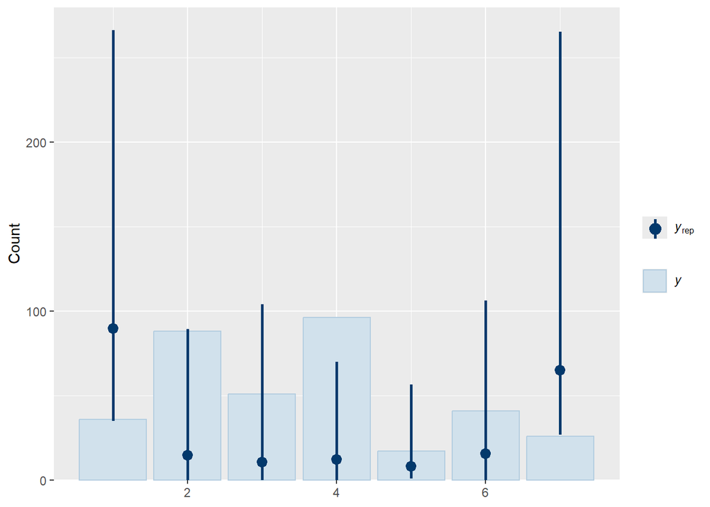

```r
m.prior <-
  brm(data = d, family = cumulative("probit"), formula = f, prior = p,
    iter = 2000, warmup = 1000, chains = 4, cores = 4,
    seed = 4, sample_prior="only",
    file = paste0("../fits/variance.", v, ".prior"), file_refit = "on_change"
  )

brms::pp_check(m.prior, ndraws=100, type = "bars")
```

The prior predictive check confirms the plausibility of the selected prior probability distribution. Given the number of predictors, the weight towards the extreme values is anticipated. Next, we update the coefficient distributions in light of the collected data using Monte Carlo Markov Chain sampling.

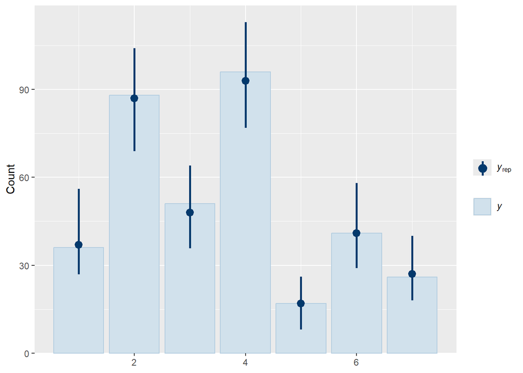

```r
m <-
  brm(data = d, family = cumulative("probit"), formula = f, prior = p,
    iter = 2000, warmup = 1000, chains = 4, cores = 4, seed = 42,
    file = paste0("../fits/variance.", v), file_refit = "on_change"
  )

brms::pp_check(m, ndraws=100, type="bars")
```

The posterior predictive check shows that the model predictions ($y_{rep}$) have grown closer to the actually observed data (`y`). This confirms that the model has trained well.

#### Evaluation

First, we can evaluate the model by visualizing the raw posterior distributions. Most of the posteriors are consistent with 0, i.e., have no significant effect on the distribution of the outcome variable.

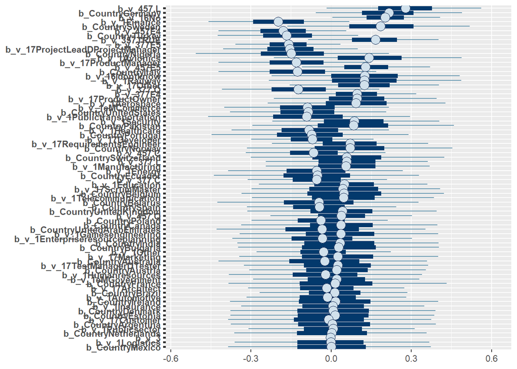

```r
posterior.distributions <- posterior_summary(m) %>%
  as.data.frame() %>%
  tibble::rownames_to_column("term") %>%
  filter(grepl("^b_", term) & !grepl("^b_Intercept", term)) %>%
  mutate(abs_est = abs(Estimate)) %>%
  arrange(desc(abs_est))

mcmc_plot(m, variable = posterior.distributions$term,
          type = "intervals", prob = 0.5, prob_outer = 0.95)
```

Next, we visualize marginal effects of individual predictors. The sector (`v_1`) hardly shows any effect on the outcome.

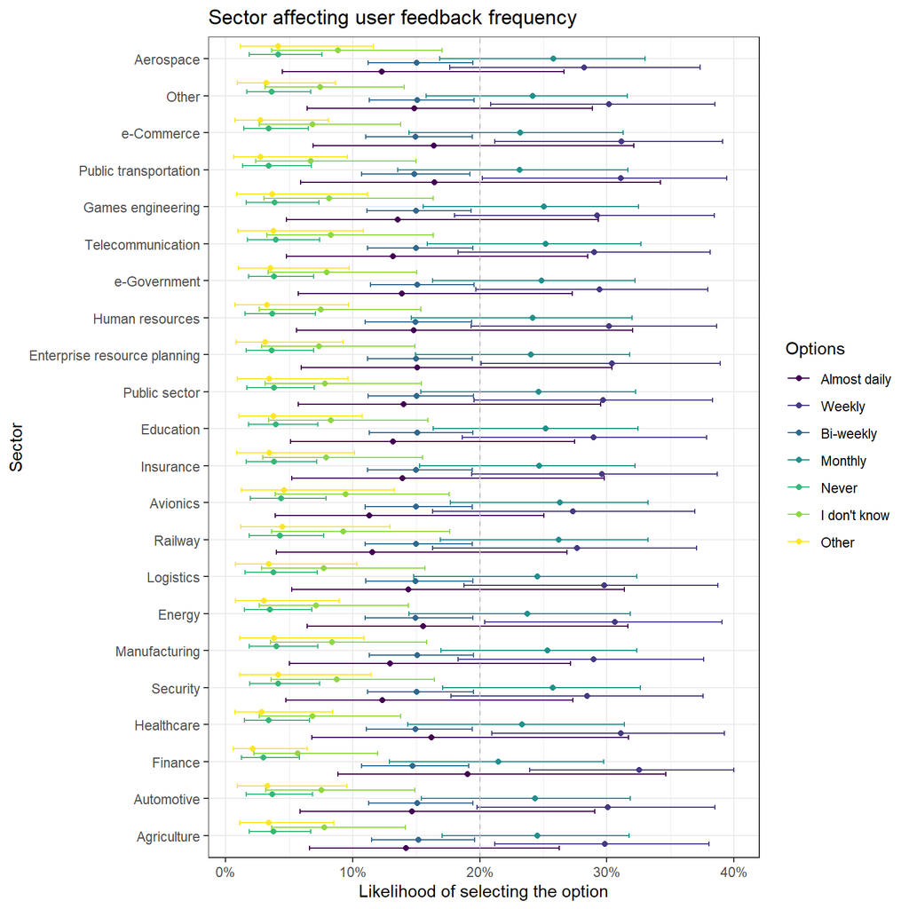

```r
conditional_effects(m, "v_1", categorical = TRUE, prob = 0.95)[[1]] %>%
  mutate(effect2__ = factor(effect2__, ordered = TRUE)) %>%
  ggplot(aes(y = effect1__, color = effect2__)) +
    geom_point(aes(x = estimate__), position = position_dodge(width = 0.8)) +
    geom_errorbar(aes(xmin = lower__, xmax = upper__), position = position_dodge(width = 0.8)) +
    geom_vline(xintercept = level.common, color = "grey", linetype = "dashed") +
    scale_x_continuous(labels = scales::percent) +
    labs(x = "Likelihood of selecting the option", y = "Sector", color = "Options") +
    ggtitle(paste0("Sector affecting ", vname)) +
    theme_bw()
```

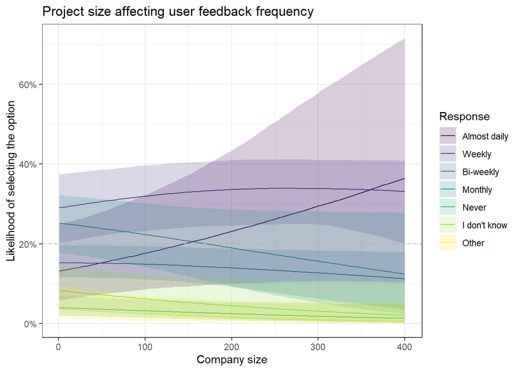

```r
conditional_effects(m, "v_3", categorical = TRUE, prob = 0.95)[[1]] %>%
  mutate(effect2__ = factor(effect2__, ordered = TRUE)) %>%
  ggplot(aes(x = effect1__)) +
    geom_line(aes(y = estimate__, color = effect2__)) +
    geom_ribbon(aes(ymin = lower__, ymax = upper__, fill = effect2__), alpha = 0.2) +
    geom_hline(yintercept = 0.2, color = "grey", linetype = "dashed") +
    labs(x = "Company size", y = "Likelihood of selecting the option",
         color = "Response", fill = "Response") +
    scale_y_continuous(labels = scales::percent) +
    ggtitle(paste0("Project size affecting ", vname)) +
    theme_bw()
```

There is hardly any variance in the response from different countries (`Country`).

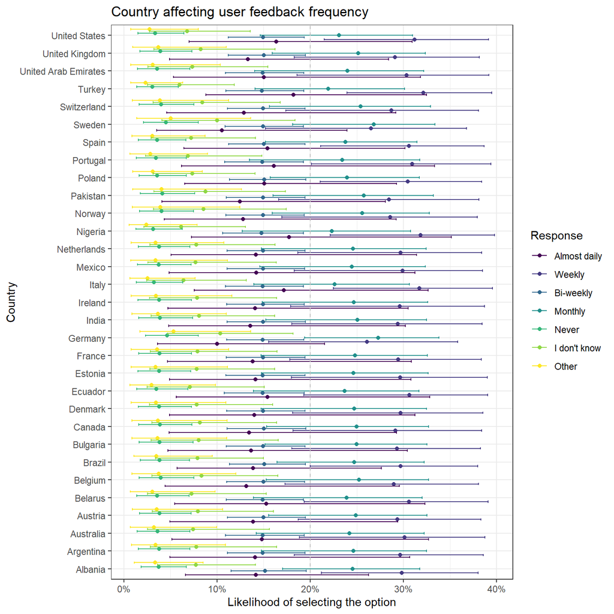

```r
conditional_effects(m, "Country", categorical = TRUE, prob = 0.95)[[1]] %>%
  mutate(effect2__ = factor(effect2__, ordered = TRUE)) %>%
  ggplot(aes(y = effect1__, color = effect2__)) +
    geom_point(aes(x = estimate__), position = position_dodge(width = 0.8)) +
    geom_errorbar(aes(xmin = lower__, xmax = upper__), position = position_dodge(width = 0.8)) +
    geom_vline(xintercept = level.common, color = "grey", linetype = "dashed") +
    scale_x_continuous(labels = scales::percent) +
    labs(x = "Likelihood of selecting the option", y = "Country", color = "Response") +
    ggtitle(paste0("Country affecting ", vname)) +
    theme_bw()
```

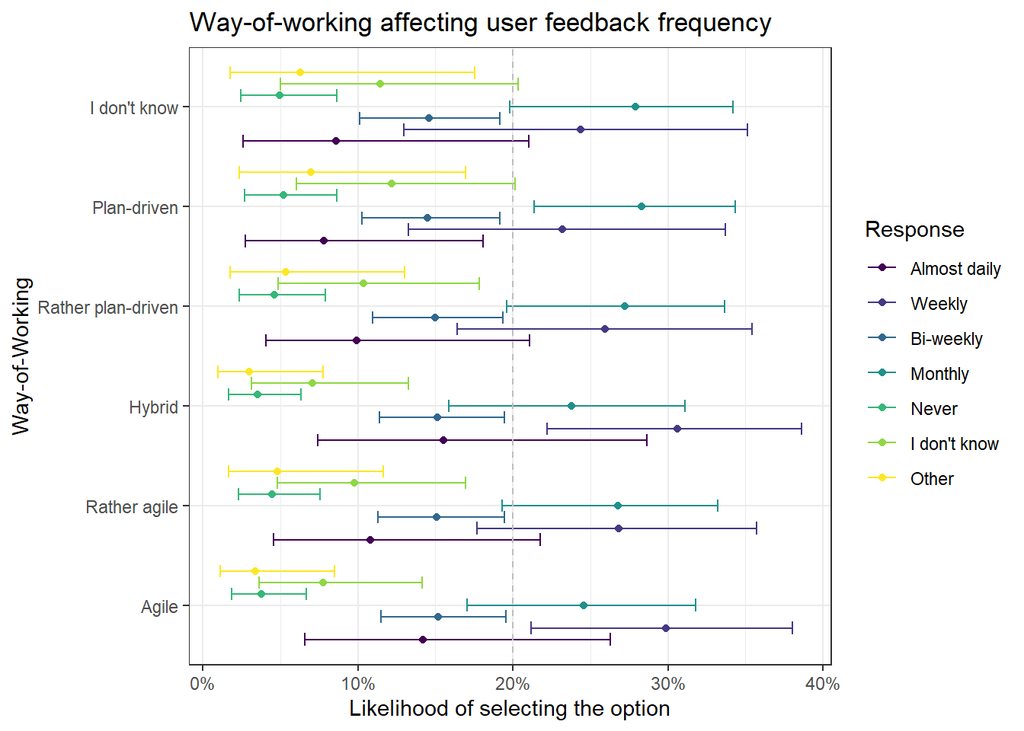

```r
conditional_effects(m, "v_457", categorical = TRUE, prob = 0.95)[[1]] %>%
  mutate(effect2__ = factor(effect2__, ordered = TRUE)) %>%
  ggplot(aes(y = effect1__, color = effect2__)) +
    geom_point(aes(x = estimate__), position = position_dodge(width = 0.8)) +
    geom_errorbar(aes(xmin = lower__, xmax = upper__), position = position_dodge(width = 0.8)) +
    geom_vline(xintercept = level.common, color = "grey", linetype = "dashed") +
    scale_x_continuous(labels = scales::percent) +
    labs(x = "Likelihood of selecting the option", y = "Way-of-Working", color = "Response") +
    ggtitle(paste0("Way-of-working affecting ", vname)) +
    theme_bw()
```

Whether or not external partners are involved (`v_16`) makes no difference in response patterns.

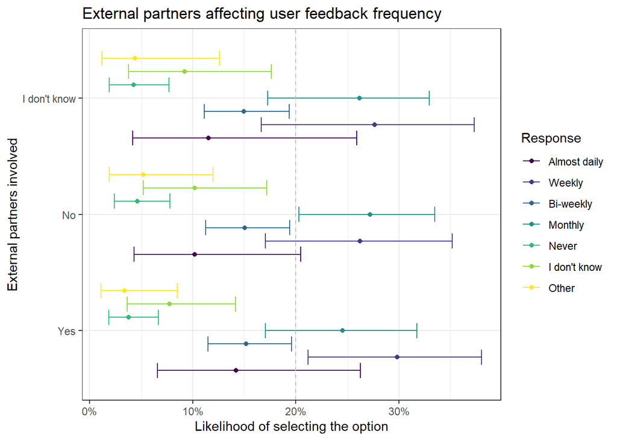

```r
conditional_effects(m, "v_16", categorical = TRUE, prob = 0.95)[[1]] %>%
  mutate(effect2__ = factor(effect2__, ordered = TRUE)) %>%
  ggplot(aes(y = effect1__, color = effect2__)) +
    geom_point(aes(x = estimate__), position = position_dodge(width = 0.8)) +
    geom_errorbar(aes(xmin = lower__, xmax = upper__), position = position_dodge(width = 0.8)) +
    geom_vline(xintercept = level.common, color = "grey", linetype = "dashed") +
    scale_x_continuous(labels = scales::percent) +
    labs(x = "Likelihood of selecting the option", y = "External partners involved", color = "Response") +
    ggtitle(paste0("External partners affecting ", vname)) +
    theme_bw()
```

Whether or not the project is distributed (`v_357`) shows little effect on the responses.

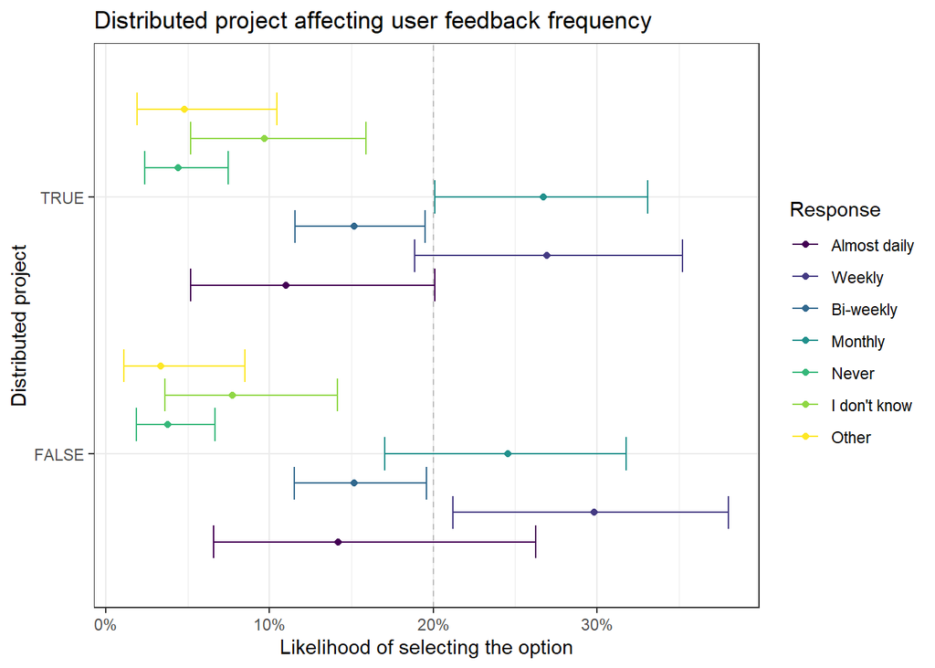

```r
conditional_effects(m, "v_357", categorical = TRUE, prob = 0.95)[[1]] %>%
  mutate(effect2__ = factor(effect2__, ordered = TRUE)) %>%
  ggplot(aes(y = effect1__, color = effect2__)) +
    geom_point(aes(x = estimate__), position = position_dodge(width = 0.8)) +
    geom_errorbar(aes(xmin = lower__, xmax = upper__), position = position_dodge(width = 0.8)) +
    geom_vline(xintercept = level.common, color = "grey", linetype = "dashed") +
    scale_x_continuous(labels = scales::percent) +
    labs(x = "Likelihood of selecting the option", y = "Distributed project", color = "Response") +
    ggtitle(paste0("Distributed project affecting ", vname)) +
    theme_bw()
```

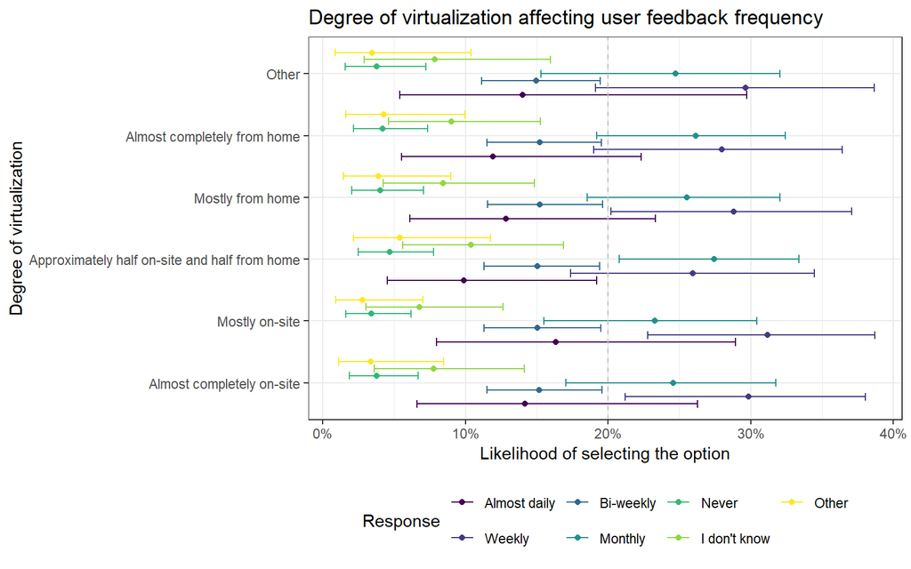

```r
conditional_effects(m, "v_377", categorical = TRUE, prob = 0.95)[[1]] %>%
  mutate(effect2__ = factor(effect2__, ordered = TRUE)) %>%
  ggplot(aes(y = effect1__, color = effect2__)) +
    geom_point(aes(x = estimate__), position = position_dodge(width = 0.8)) +
    geom_errorbar(aes(xmin = lower__, xmax = upper__), position = position_dodge(width = 0.8)) +
    geom_vline(xintercept = level.common, color = "grey", linetype = "dashed") +
    scale_x_continuous(labels = scales::percent) +
    labs(x = "Likelihood of selecting the option", y = "Degree of virtualization", color = "Response") +
    ggtitle(paste0("Degree of virtualization affecting ", vname)) +
    theme_bw() +
    theme(legend.position = "bottom")
```

The role of respondents (`v_17`) does not show a significant effect.

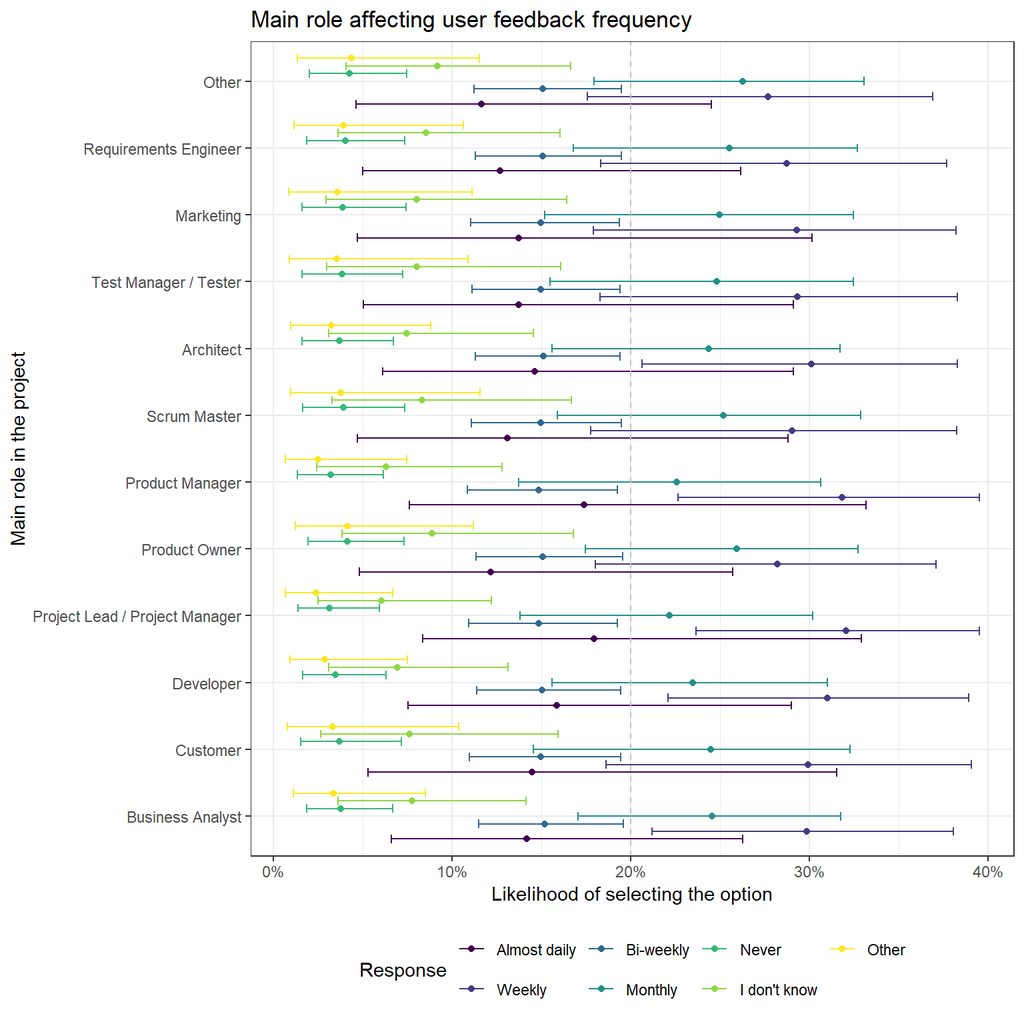

```r
conditional_effects(m, "v_17", categorical = TRUE, prob = 0.95)[[1]] %>%
  mutate(effect2__ = factor(effect2__, ordered = TRUE)) %>%
  ggplot(aes(y = effect1__, color = effect2__)) +
    geom_point(aes(x = estimate__), position = position_dodge(width = 0.8)) +
    geom_errorbar(aes(xmin = lower__, xmax = upper__), position = position_dodge(width = 0.8)) +
    geom_vline(xintercept = level.common, color = "grey", linetype = "dashed") +
    scale_x_continuous(labels = scales::percent) +
    labs(x = "Likelihood of selecting the option", y = "Main role in the project", color = "Response") +
    ggtitle(paste0("Main role affecting ", vname)) +
    theme_bw() +
    theme(legend.position = "bottom")
```

[^1]: Siebert, J. (2023). Applications of statistical causal inference in software engineering. Information and Software Technology, 159, 107198.
[^2]: McElreath, R. (2018). Statistical rethinking: A Bayesian course with examples in R and Stan. Chapman and Hall/CRC.